# Predicción de bancarrota empresarial

En este proyecto, se utilizan datos reales para predecir el si una empresa se declarará en bancarrota en el año siguiente a la observación de su información financiera. Para cada empresa, se tienen en total 63 razones financieras calculadas y la muestra corresponde a compañías en China durante los años de 1999 a 2009 que aparecen en el Shanghai Stock Exchange.

A continuación, se presentan las etapas para realizar un modelamiento predictivo de bancarrota empresarial mediante el uso de redes neuronales MLP. El informe se divide en las siguientes secciones:

1. Exploración de los datos (10 puntos)
2. Preparación de los datos (10 puntos)
3. Análisis preliminar de selección de modelos (20 puntos)
4. Desarrollo y calibración de modelos (40 puntos)
5. Visualización de resultados (20 puntos)

Autores:

- Ibeth Karine Terán
- Sebastian Morales
- Diego Tibaduisa

## 1. Exploración de los datos

La sección de Exploración de Datos tiene como objetivo entender la estructura, características y calidad del conjunto de datos. Aquí se realiza un análisis descriptivo inicial que incluye la revisión de las dimensiones del dataset, tipos de variables, valores faltantes, estadísticas descripotivas y patrones relevantes.

Esta etapa es fundamental para identificar posibles inconsistencias, detectar tendencias o relaciones entre variables, y definir estrategias de limpieza y preparación de los datos para la etapa de preparación.

### Importación de librerías

```python
import pandas as pd
import numpy as np
import matplotlib.pyplot as plt
import seaborn as sns

# Configuraciones estéticas
sns.set(style="whitegrid")
plt.rcParams["figure.figsize"] = (12, 6)
```

### Cargue de datos

```python
# Cargar archivos (rutas relativas)
train = pd.read_csv("../data/raw/train_data.csv")
test = pd.read_csv("../data/raw/test_data.csv")
sample_submission = pd.read_csv("../data/raw/sampleSubmission.csv")
```

### Información general

#### Tamaño y visualización de los datasets

```python
# Tamaño de los datasets
print("Tamaño Train:", train.shape)
print("Tamaño Test:", test.shape)
```

```
Tamaño Train: (2050, 65)
Tamaño Test: (500, 64)
```

```python
train
```

|  | ID | Bankruptcy | Realized.Sales.Gross.Profit.Growth.Rate | Operating.Expense.Rate | Operating.Profit.Per.Share..Yuan... | Gross.Profit.to.Sales | Tax.rate..A. | Current.Liability.to.Liability | Continuous.Net.Profit.Growth.Rate | Long.term.Liability.to.Current.Assets | ... | Per.Share.Net.profit.before.tax..Yuan... | Continuous.interest.rate..after.tax. | Liability.Assets.Flag | Working.Capital.to.Total.Assets | Degree.of.Financial.Leverage..DFL. | Operating.Gross.Margin | Contingent.liabilities.Net.worth | Operating.Profit.Growth.Rate | Cash.Flow.to.Liability | Quick.Assets.Total.Assets |
| --- | --- | --- | --- | --- | --- | --- | --- | --- | --- | --- | --- | --- | --- | --- | --- | --- | --- | --- | --- | --- | --- |
| 0 | 1 | 0 | 0.087661 | 1.900349e-04 | 0.131094 | 0.583345 | 0.000000 | 0.815892 | 0.395719 | 0.089276 | ... | 0.223720 | 0.801737 | 0 | 0.839112 | 0.036551 | 0.591350 | 0.007401 | 0.913175 | 0.489822 | 0.138714 |
| 1 | 2 | 0 | 0.021892 | 5.371576e-04 | 0.086167 | 0.695478 | 0.209649 | 0.768636 | 0.163505 | 0.000000 | ... | 0.324763 | 0.791203 | 0 | 0.908450 | 0.126752 | 0.766066 | 0.020514 | 0.849241 | 0.550247 | 0.704211 |
| 2 | 3 | 0 | 0.102249 | 2.178329e-04 | 0.157755 | 0.766934 | 0.272061 | 0.643316 | 0.181571 | 0.010180 | ... | 0.360892 | 0.803126 | 0 | 0.865943 | 0.018152 | 0.687211 | 0.004363 | 0.865814 | 0.447168 | 0.398086 |
| 3 | 4 | 0 | 0.029972 | 4.915756e+10 | 0.249279 | 0.611580 | 0.288357 | 0.752782 | 0.409196 | 0.018603 | ... | 0.152445 | 0.824732 | 0 | 0.806254 | 0.051284 | 0.715973 | 0.014162 | 0.843357 | 0.485163 | 0.617386 |
| 4 | 6 | 0 | 0.021164 | 1.206001e-04 | 0.239817 | 0.614250 | 0.000000 | 0.559498 | 0.286989 | 0.148687 | ... | 0.217282 | 0.787010 | 0 | 0.769843 | 0.012872 | 0.704043 | 0.003050 | 0.884905 | 0.422001 | 0.187121 |
| ... | ... | ... | ... | ... | ... | ... | ... | ... | ... | ... | ... | ... | ... | ... | ... | ... | ... | ... | ... | ... | ... |
| 2045 | 2545 | 0 | 0.067900 | 7.201851e+05 | 0.334972 | 0.564459 | 0.166696 | 0.889719 | 0.277489 | 0.005494 | ... | 0.177566 | 0.793529 | 0 | 0.860448 | 0.020242 | 0.720086 | 0.006337 | 0.867445 | 0.443956 | 0.699702 |
| 2046 | 2546 | 0 | 0.067735 | 2.380508e-05 | 0.193017 | 0.736555 | 0.089094 | 0.738665 | 0.348624 | 0.007731 | ... | 0.383780 | 0.830696 | 0 | 0.842840 | 0.159408 | 0.603963 | 0.025980 | 0.824779 | 0.550102 | 0.551980 |
| 2047 | 2547 | 0 | 0.068447 | 8.325822e-05 | 0.109198 | 0.734305 | 0.000000 | 0.534512 | 0.404424 | 0.029523 | ... | 0.265202 | 0.757833 | 0 | 0.759694 | 0.026616 | 0.741242 | 0.007079 | 0.876836 | 0.666202 | 0.311649 |
| 2048 | 2548 | 0 | 0.017600 | 9.098720e-03 | 0.279550 | 0.757877 | 0.492404 | 0.806436 | 0.175130 | 0.014910 | ... | 0.380793 | 0.799704 | 0 | 0.791138 | 0.136190 | 0.656832 | 0.003518 | 0.900142 | 0.471446 | 0.401341 |
| 2049 | 2550 | 0 | 0.136419 | 4.421828e+07 | 0.200310 | 0.561358 | 0.126222 | 0.641650 | 0.283364 | 0.025015 | ... | 0.308645 | 0.761051 | 0 | 0.735188 | 0.042556 | 0.591996 | 0.005567 | 0.906222 | 0.485466 | 0.303517 |

2050 rows × 65 columns

```python
test.head(5)
```

|  | ID | Realized.Sales.Gross.Profit.Growth.Rate | Operating.Expense.Rate | Operating.Profit.Per.Share..Yuan... | Gross.Profit.to.Sales | Tax.rate..A. | Current.Liability.to.Liability | Continuous.Net.Profit.Growth.Rate | Long.term.Liability.to.Current.Assets | Total.assets.to.GNP.price | ... | Per.Share.Net.profit.before.tax..Yuan... | Continuous.interest.rate..after.tax. | Liability.Assets.Flag | Working.Capital.to.Total.Assets | Degree.of.Financial.Leverage..DFL. | Operating.Gross.Margin | Contingent.liabilities.Net.worth | Operating.Profit.Growth.Rate | Cash.Flow.to.Liability | Quick.Assets.Total.Assets |
| --- | --- | --- | --- | --- | --- | --- | --- | --- | --- | --- | --- | --- | --- | --- | --- | --- | --- | --- | --- | --- | --- |
| 0 | 5 | 0.055077 | 1.064430e-02 | 0.131220 | 0.657541 | 0.118122 | 0.771297 | 0.366505 | 0.018675 | 0.001246 | ... | 0.197730 | 0.786381 | 0 | 0.828263 | 0.024649 | 0.645659 | 0.052743 | 0.913336 | 0.557402 | 0.360819 |
| 1 | 14 | 0.020286 | 6.654634e+07 | 0.247104 | 0.746134 | 0.000000 | 0.697656 | 0.313514 | 0.126093 | 0.006813 | ... | 0.254563 | 0.850153 | 0 | 0.684968 | 0.075233 | 0.723486 | 0.003821 | 0.851428 | 0.584835 | 0.058199 |
| 2 | 16 | 0.040610 | 8.415991e+08 | 0.164832 | 0.718794 | 0.130647 | 0.398228 | 0.239002 | 0.122627 | 0.002547 | ... | 0.186794 | 0.808544 | 0 | 0.888590 | 0.078625 | 0.737439 | 0.070270 | 0.832491 | 0.409327 | 0.449420 |
| 3 | 26 | 0.067641 | 1.344961e-04 | 0.153400 | 0.741510 | 0.000000 | 0.842550 | 0.348637 | 0.007500 | 0.000219 | ... | 0.401842 | 0.830902 | 0 | 0.800685 | 0.158704 | 0.610681 | 0.012037 | 0.824596 | 0.561291 | 0.449031 |
| 4 | 28 | 0.017546 | 6.125562e-03 | 0.208468 | 0.743188 | 0.317456 | 0.387746 | 0.175101 | 0.039756 | 0.008112 | ... | 0.329068 | 0.799609 | 0 | 0.824782 | 0.136387 | 0.637626 | 0.003518 | 0.900079 | 0.477007 | 0.395706 |

5 rows × 64 columns

#### Tipos de datos

La exploración se enfoca en el dataset de train, ya que es el conjunto de datos que se utilizará para el desarrollo de los modelos predictivos.

La variable objetivo es "Bankruptcy", la cual es una variable binaria que toma el valor de 1 si la empresa está en bancarrota y 0 si no lo está.

```python
# Tipos de datos y valores nulos
train.info()
```

```
<class 'pandas.core.frame.DataFrame'>
RangeIndex: 2050 entries, 0 to 2049
Data columns (total 65 columns):
 #   Column                                              Non-Null Count  Dtype
---  ------                                              --------------  -----
 0   ID                                                  2050 non-null   int64
 1   Bankruptcy                                          2050 non-null   int64
 2   Realized.Sales.Gross.Profit.Growth.Rate             2050 non-null   float64
 3   Operating.Expense.Rate                              2050 non-null   float64
 4   Operating.Profit.Per.Share..Yuan...                 2050 non-null   float64
 5   Gross.Profit.to.Sales                               2050 non-null   float64
 6   Tax.rate..A.                                        2050 non-null   float64
 7   Current.Liability.to.Liability                      2050 non-null   float64
 8   Continuous.Net.Profit.Growth.Rate                   2050 non-null   float64
 9   Long.term.Liability.to.Current.Assets               2050 non-null   float64
```

[output cut: 57 more lines]

#### Estadístias descriptivas

```python
# Estadísticas descriptivas
train.describe().T
```

|  | count | mean | std | min | 25% | 50% | 75% | max |
| --- | --- | --- | --- | --- | --- | --- | --- | --- |
| ID | 2050.0 | 1.276675e+03 | 7.337705e+02 | 1.000000 | 645.250000 | 1286.500000 | 1.902750e+03 | 2.550000e+03 |
| Bankruptcy | 2050.0 | 3.024390e-02 | 1.712995e-01 | 0.000000 | 0.000000 | 0.000000 | 0.000000e+00 | 1.000000e+00 |
| Realized.Sales.Gross.Profit.Growth.Rate | 2050.0 | 5.242644e-02 | 3.734597e-02 | 0.005576 | 0.022660 | 0.039844 | 7.413378e-02 | 1.976222e-01 |
| Operating.Expense.Rate | 2050.0 | 1.143592e+10 | 6.637064e+10 | 0.000018 | 0.000387 | 0.002891 | 2.040574e+06 | 8.153957e+11 |
| Operating.Profit.Per.Share..Yuan... | 2050.0 | 1.684231e-01 | 7.482216e-02 | 0.026690 | 0.107202 | 0.153541 | 2.197845e-01 | 4.024868e-01 |
| ... | ... | ... | ... | ... | ... | ... | ... | ... |
| Operating.Gross.Margin | 2050.0 | 6.595301e-01 | 6.430054e-02 | 0.449928 | 0.608820 | 0.654584 | 7.120428e-01 | 8.083387e-01 |
| Contingent.liabilities.Net.worth | 2050.0 | 2.062910e-02 | 1.928225e-02 | 0.001931 | 0.005786 | 0.012352 | 2.978119e-02 | 9.671401e-02 |
| Operating.Profit.Growth.Rate | 2050.0 | 8.707365e-01 | 2.806991e-02 | 0.808653 | 0.848945 | 0.869933 | 8.936929e-01 | 9.212760e-01 |
| Cash.Flow.to.Liability | 2050.0 | 5.284203e-01 | 8.417075e-02 | 0.078139 | 0.462781 | 0.519719 | 5.964921e-01 | 1.000000e+00 |
| Quick.Assets.Total.Assets | 2050.0 | 4.621027e-01 | 2.114766e-01 | 0.004725 | 0.295769 | 0.458141 | 6.208409e-01 | 9.896206e-01 |

65 rows × 8 columns

Sección 4: Revisión de la variable objetivo

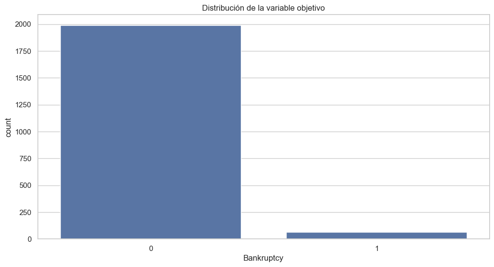

```
Tasa de bancarrota: 3.02%
```

```python
# Distribución de la variable objetivo
sns.countplot(x='Bankruptcy', data=train)
plt.title('Distribución de la variable objetivo')
plt.show()

# Porcentaje de casos positivos (bancarrota)
bankrupt_rate = train['Bankruptcy'].mean()
print(f"Tasa de bancarrota: {bankrupt_rate:.2%}")
```

Sección 5: Detección de valores faltantes

```python
# Porcentaje de valores nulos por columna
nulls = train.isnull().mean().sort_values(ascending=False)
nulls[nulls > 0]
```

```
Series([], dtype: float64)
```

```python
# Validar duplicados exactos (todas las columnas)
duplicados = train.duplicated()

print(f"Número de registros duplicados: {duplicados.sum()}")

# Eliminar duplicados si los hay
if duplicados.sum() > 0:
    train = train.drop_duplicates()
    print(f"Se eliminaron {duplicados.sum()} registros duplicados.")
```

```
Número de registros duplicados: 0
```

Sección 6: valores atípicos

```python
# Selección de variables numéricas (excluyendo la variable objetivo)
variables_numericas = train.drop(columns=['Bankruptcy']).select_dtypes(include='number').columns
print("Variables numéricas:", variables_numericas.shape[0])
```

```
Variables numéricas: 64
```

```python
# Función para detectar valores atípicos usando el rango intercuartílico (IQR)
def detectar_outliers_iqr(df, col):
    Q1 = df[col].quantile(0.25)
    Q3 = df[col].quantile(0.75)
    IQR = Q3 - Q1
    outliers = df[(df[col] < Q1 - 1.5 * IQR) | (df[col] > Q3 + 1.5 * IQR)]
    return outliers.shape[0]

# Número de valores atípicos por columna
outliers_por_col = {col: detectar_outliers_iqr(train, col) for col in variables_numericas}
outliers_df = pd.DataFrame.from_dict(outliers_por_col, orient='index', columns=['N_outliers'])
outliers_df.sort_values(by='N_outliers', ascending=False).head(10)
```

|  | N_outliers |
| --- | --- |
| Operating.Expense.Rate | 485 |
| Quick.Asset.Turnover.Rate | 463 |
| Fixed.Assets.Turnover.Frequency | 417 |
| Current.Asset.Turnover.Rate | 400 |
| Total.Asset.Growth.Rate | 383 |
| Interest.bearing.debt.interest.rate | 244 |
| Long.term.Liability.to.Current.Assets | 220 |
| Total.assets.to.GNP.price | 195 |
| Cash.Current.Liability | 177 |
| Revenue.per.person | 158 |

Sección 7: Análisis de correlaciones

```
Debt.ratio..                             0.151972
Current.Liability.to.Current.Assets      0.151521
Current.Liability.to.Assets              0.142689
Liability.Assets.Flag                    0.125095
Revenue.per.person                       0.125095
Quick.Ratio                              0.125083
Long.term.Liability.to.Current.Assets    0.088551
Total.expense.Assets                     0.074570
Equity.to.Long.term.Liability            0.061244
Borrowing.dependency                     0.055949
Name: Bankruptcy, dtype: float64
Persistent.EPS.in.the.Last.Four.Seasons             -0.081034
Net.Income.to.Stockholder.s.Equity                  -0.092259
Net.Value.Per.Share..B.                             -0.105821
Cash.Total.Assets                                   -0.108185
Quick.Assets.Total.Assets                           -0.123639
Tax.rate..A.                                        -0.136000
ROA.B..before.interest.and.depreciation.after.tax   -0.161663
Working.Capital.to.Total.Assets                     -0.185094
Retained.Earnings.to.Total.Assets                   -0.196102
Net.Income.Flag                                           NaN
Name: Bankruptcy, dtype: float64
```

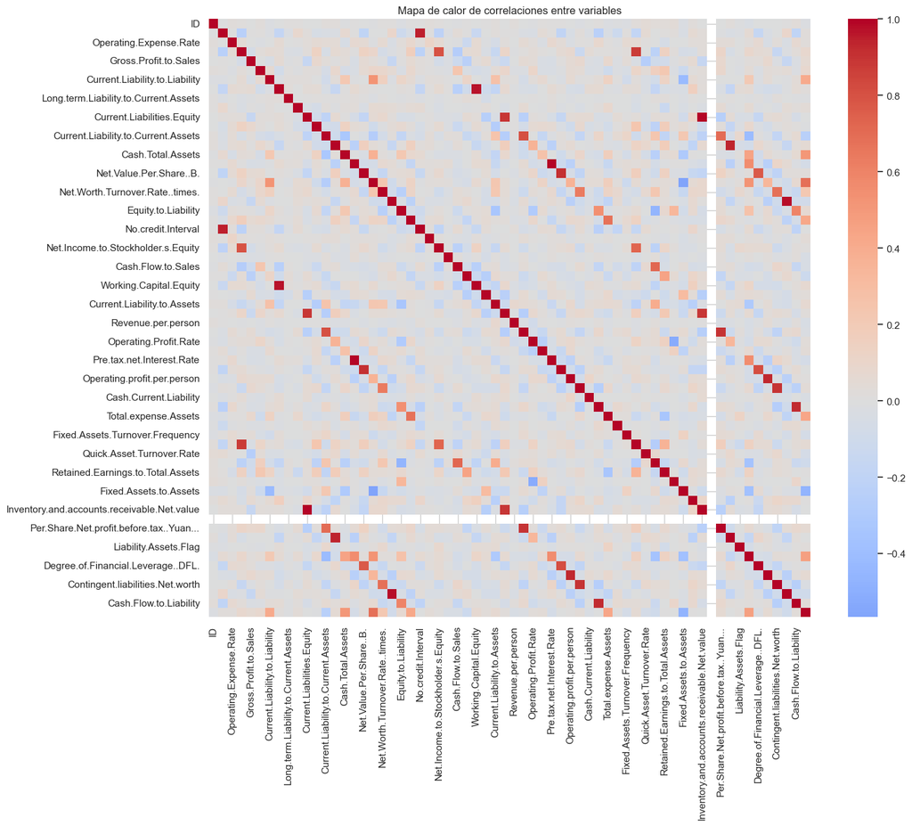

```python
# Correlación con la variable objetivo
cor_target = train.corr()["Bankruptcy"].sort_values(ascending=False)
cor_target.drop(['ID', 'Bankruptcy'], inplace=True)
print(cor_target.head(10))  # Las más correlacionadas positivamente
print(cor_target.tail(10))  # Las más correlacionadas negativamente

# Mapa de calor de correlaciones
plt.figure(figsize=(15, 12))
corr_matrix = train.drop(columns=['Bankruptcy']).corr()
sns.heatmap(corr_matrix, cmap="coolwarm", center=0)
plt.title("Mapa de calor de correlaciones entre variables")
plt.show()
```

```python
# Matriz de correlación alta (superior a 0.90)
cor_matrix = train[variables_numericas].corr().abs()
alta_cor = cor_matrix.where(np.triu(np.ones(cor_matrix.shape), k=1).astype(bool))
pares_altamente_correlacionados = [(col, alta_cor[col].idxmax(), alta_cor[col].max())
                                   for col in alta_cor.columns if alta_cor[col].max() > 0.90]

print("Pares de variables altamente correlacionadas (> 0.90):")
for par in pares_altamente_correlacionados:
    print(f"{par[0]} y {par[1]} — Correlación: {par[2]:.2f}")
```

```
Pares de variables altamente correlacionadas (> 0.90):
No.credit.Interval y Realized.Sales.Gross.Profit.Growth.Rate — Correlación: 0.95
Working.Capital.Equity y Continuous.Net.Profit.Growth.Rate — Correlación: 0.97
Pre.tax.net.Interest.Rate y Inventory.Working.Capital — Correlación: 0.99
After.tax.Net.Profit.Growth.Rate y Net.Value.Per.Share..B. — Correlación: 0.91
Inventory.and.accounts.receivable.Net.value y Current.Liabilities.Equity — Correlación: 1.00
Continuous.interest.rate..after.tax. y Persistent.EPS.in.the.Last.Four.Seasons — Correlación: 0.93
Operating.Gross.Margin y Operating.profit.per.person — Correlación: 0.93
Operating.Profit.Growth.Rate y Interest.Coverage.Ratio..Interest.expense.to.EBIT. — Correlación: 0.98
Cash.Flow.to.Liability y Current.Liability.to.Equity — Correlación: 0.92
```

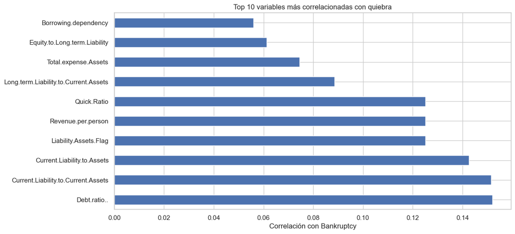

```python
# Gráfica de las 10 variables más correlacionadas con la variable objetivo
cor_target.head(10).plot(kind='barh')
plt.title('Top 10 variables más correlacionadas con quiebra')
plt.xlabel('Correlación con Bankruptcy')
plt.show()
```

Sección 8: Graficos de variables seleccionadas

```
Generando y guardando boxplots...
```

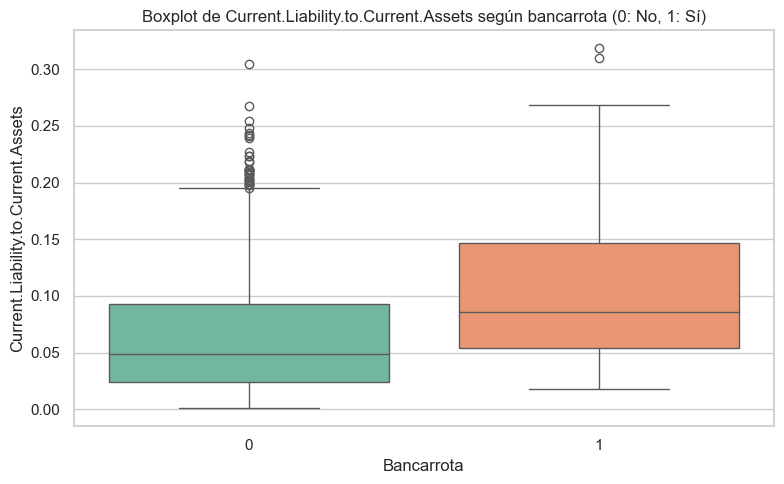

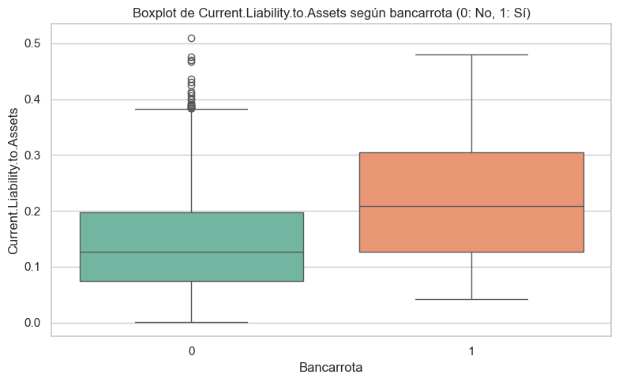

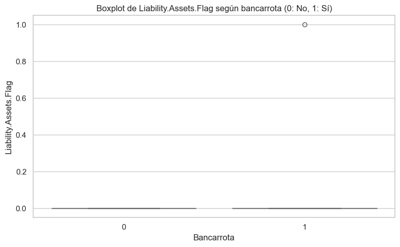

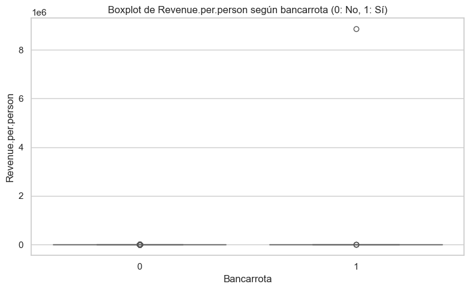

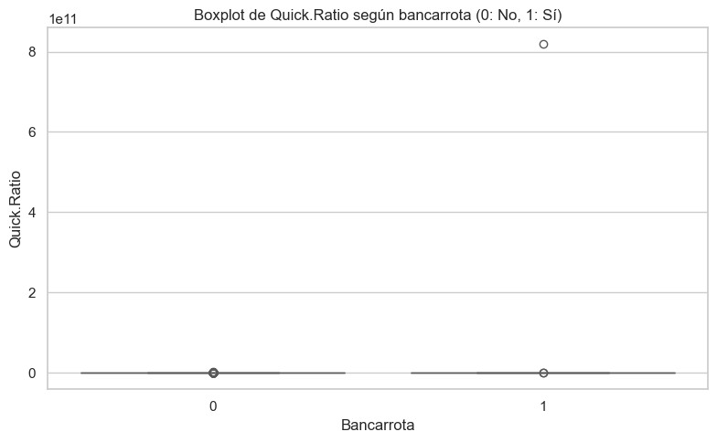

```python
# Seleccionamos las 5 variables más correlacionadas con 'Bankruptcy'
variables_interes = cor_target[1:6].index.tolist()

# Boxplots
print("Generando y guardando boxplots...\n")
for variable in variables_interes:
    plt.figure(figsize=(8, 5))
    sns.boxplot(
        data=train,
        x='Bankruptcy',
        y=variable,
        hue='Bankruptcy',
        palette='Set2',
        legend=False
    )
    plt.title(f'Boxplot de {variable} según bancarrota (0: No, 1: Sí)')
    plt.xlabel('Bancarrota')
    plt.ylabel(variable)
    plt.tight_layout()
    #plt.savefig(f"../outputs/figures/boxplot_{variable}.png")
    plt.show()  # Mostrar la figura para visualizarla en el notebook
    plt.close()  # Cerrar la figura para liberar memoria
```

```
Generando y guardando histogramas...
```

[figure not shown]

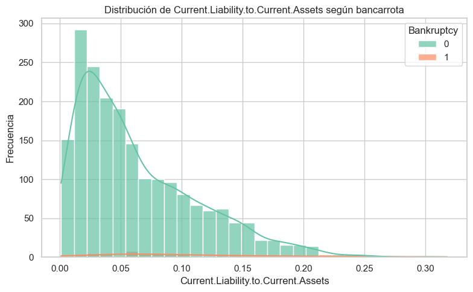

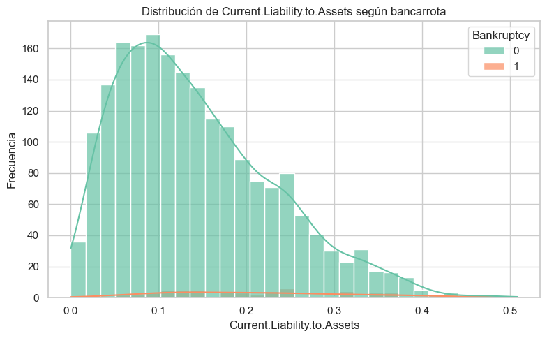

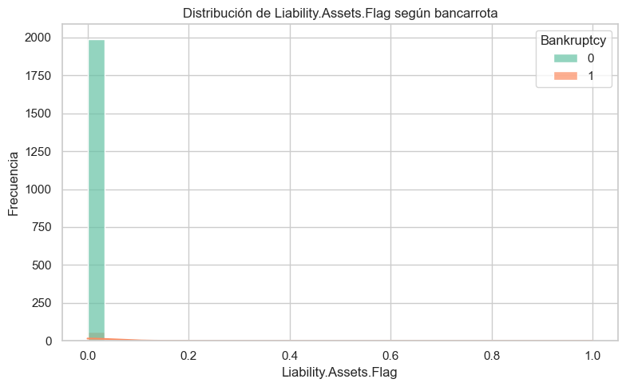

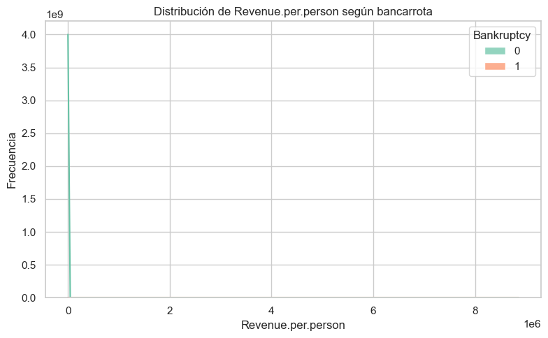

```python
# Histogramas
print("Generando y guardando histogramas...\n")
for variable in variables_interes:
    plt.figure(figsize=(8, 5))
    sns.histplot(
        data=train,
        x=variable,
        hue='Bankruptcy',
        bins=30,
        kde=True,
        palette='Set2',
        alpha=0.7
    )
    plt.title(f'Distribución de {variable} según bancarrota')
    plt.xlabel(variable)
    plt.ylabel('Frecuencia')
    plt.tight_layout()
    plt.savefig(f"../outputs/figures/histogram_{variable}.png")
    plt.show()  # Mostrar la figura para visualizarla en el notebook
    plt.close()  # Cerrar la figura para liberar memoria
```

Sección 9: Validaciones calidad de datos

```python
# Revisar columnas con posibles restricciones lógicas (ej. solo valores positivos)
variables_potencialmente_positivas = [
    'Operating.Profit.Per.Share..Yuan...',
    'Revenue.per.person',
    'Operating.profit.per.person',
    'Cash.Total.Assets'
]

for col in variables_potencialmente_positivas:
    print(f"{col}: valores <= 0 = {(train[col] <= 0).sum()}")
```

```
Operating.Profit.Per.Share..Yuan...: valores <= 0 = 0
Revenue.per.person: valores <= 0 = 0
Operating.profit.per.person: valores <= 0 = 0
Cash.Total.Assets: valores <= 0 = 0
```

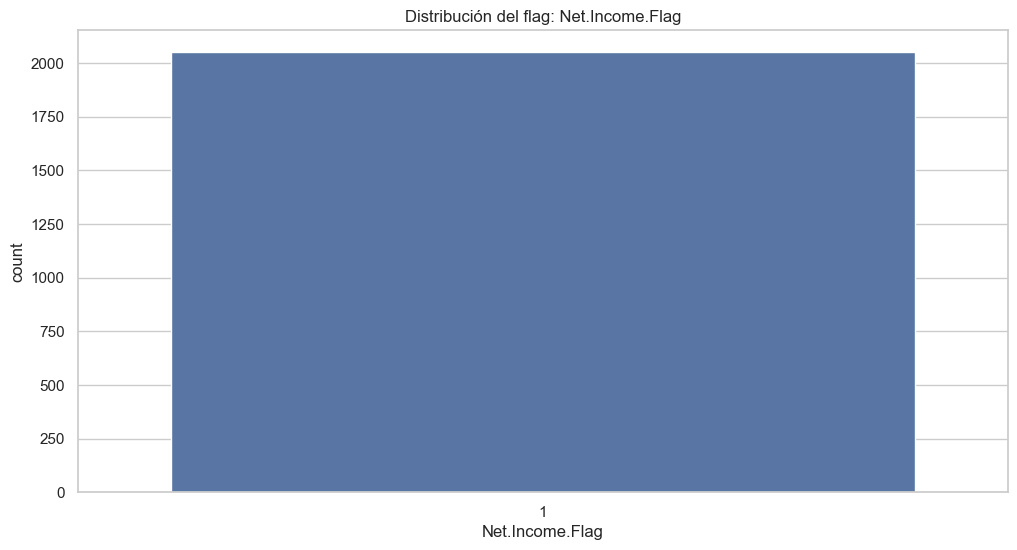

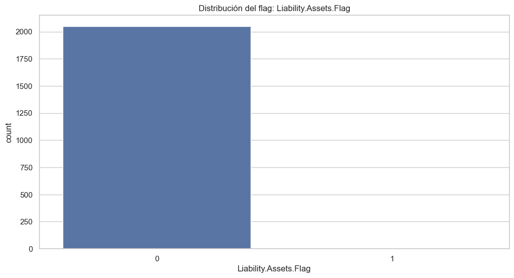

```python
# Identificación de variables binarias
flags = ['Net.Income.Flag', 'Liability.Assets.Flag']

for flag in flags:
    sns.countplot(x=flag, data=train)
    plt.title(f'Distribución del flag: {flag}')
    plt.show()
    plt.close()  # Cerrar la figura para liberar memoria
```

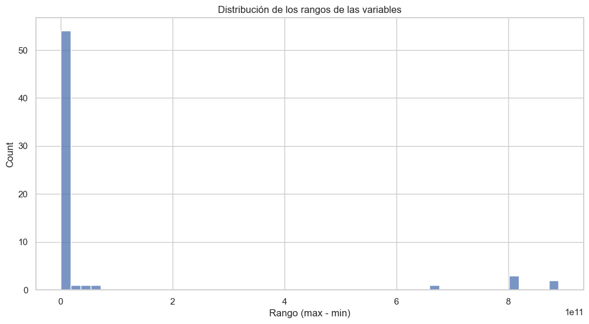

```python
# Revisión de escalas muy dispares (rangos extremos)
# Rango = max - min
rangos = train.drop(columns=['ID', 'Bankruptcy']).apply(lambda x: x.max() - x.min())
rangos.sort_values(ascending=False).head(10)  # Rangos más altos

# Histograma de los rangos
plt.figure(figsize=(12, 6))
sns.histplot(rangos, bins=50)
plt.title('Distribución de los rangos de las variables')
plt.xlabel('Rango (max - min)')
plt.show()
plt.close()  # Cerrar la figura para liberar memoria
```

Sección 10: Conclusiones preliminares

# 📌 Conclusiones preliminares